# Assignment 1 Correlation and Simple Linear Regression

Tom Rozanov

2022-09-09

## Simple Linear Regression Assignment 1

### Tom Rozanov BAN 502

```r
library(tidyverse)
library(tidymodels)
library(GGally)
library(lmtest)
```

```r
library(esquisse) #optional for ggplot functions
#Install required packages
```

```r
air = airquality #read-in data set as "air" d.f.
```

*Question 1 How many rows are in the “air” dataframe?*

*Question 2 How many columns are in the “air” dataframe?*

*Question 3 True/False: There is missing data in “Ozone” variable in the dataframe.*

```r
str(air)
```

```
## 'data.frame':    153 obs. of  6 variables:
##  $ Ozone  : int  41 36 12 18 NA 28 23 19 8 NA ...
##  $ Solar.R: int  190 118 149 313 NA NA 299 99 19 194 ...
##  $ Wind   : num  7.4 8 12.6 11.5 14.3 14.9 8.6 13.8 20.1 8.6 ...
##  $ Temp   : int  67 72 74 62 56 66 65 59 61 69 ...
##  $ Month  : int  5 5 5 5 5 5 5 5 5 5 ...
##  $ Day    : int  1 2 3 4 5 6 7 8 9 10 ...
```

```r
summary(air)
```

```
##      Ozone           Solar.R           Wind             Temp
##  Min.   :  1.00   Min.   :  7.0   Min.   : 1.700   Min.   :56.00
##  1st Qu.: 18.00   1st Qu.:115.8   1st Qu.: 7.400   1st Qu.:72.00
##  Median : 31.50   Median :205.0   Median : 9.700   Median :79.00
##  Mean   : 42.13   Mean   :185.9   Mean   : 9.958   Mean   :77.88
##  3rd Qu.: 63.25   3rd Qu.:258.8   3rd Qu.:11.500   3rd Qu.:85.00
##  Max.   :168.00   Max.   :334.0   Max.   :20.700   Max.   :97.00
##  NA's   :37       NA's   :7
##      Month            Day
##  Min.   :5.000   Min.   : 1.0
##  1st Qu.:6.000   1st Qu.: 8.0
##  Median :7.000   Median :16.0
##  Mean   :6.993   Mean   :15.8
##  3rd Qu.:8.000   3rd Qu.:23.0
##  Max.   :9.000   Max.   :31.0
##
```

```r
#examine structure of "air" data frame to answer rows & columns question
#examine summary of "air" data frame to answer missing data question
```

Responses:

Q1: There are 153 rows in the “air” dataframe.

Q2: There are 6 columns/variables in the “air” data frame

Q3: True. There are 37 missing rows (“NA”) in the “Ozone” variable in the data frame

*Question 4 Which variable is most likely to be the response (Y) variable?*

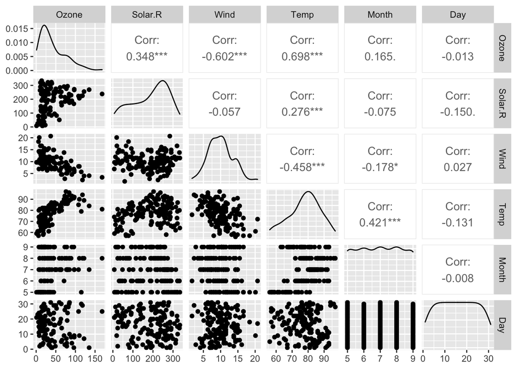

```r
ggpairs(air) #examine data for possible response variables
```

Q4: Ozone is the most likely to be the response variable (Y) because it has the highest correlations among other variables. Additionally, by looking at the link here https://stat.ethz.ch/R-manual/R-devel/library/datasets/html/airquality.html we can see that “Ozone” represents: mean ozone in parts per billion from 1300 to 1500 hours at Roosevelt Island.

*We have three approaches that we can typically select from to deal with missing data:*

1. Delete the rows with missing data
2. Delete the columns with missing data
3. Impute (i.e., estimate or guess) values to replace the missing values

Here we’ll choose to delete rows with any missing data. Use the code below to apply the “drop_na” function to the “air” dataframe. The resulting dataframe will be called “air2”. You will use this dataframe for the remainder of the assignment.

```r
air2 = air %>% drop_na() #dropping missing values in the "air2" dataframe
```

**Question 5 How many rows remain in this new (air2) data frame?**

**Question 6 How many columns remain in this new (air2) data frame?**

```r
str(air2)
```

```
## 'data.frame':    111 obs. of  6 variables:
##  $ Ozone  : int  41 36 12 18 23 19 8 16 11 14 ...
##  $ Solar.R: int  190 118 149 313 299 99 19 256 290 274 ...
##  $ Wind   : num  7.4 8 12.6 11.5 8.6 13.8 20.1 9.7 9.2 10.9 ...
##  $ Temp   : int  67 72 74 62 65 59 61 69 66 68 ...
##  $ Month  : int  5 5 5 5 5 5 5 5 5 5 ...
##  $ Day    : int  1 2 3 4 7 8 9 12 13 14 ...
```

Use the “ggpairs” function to develop a visualization of the relationships in this dataset and to show correlation values for the combinations of variables.

Then use the “ggcorr” function to develop a correlation matrix for the variables. Hint: Use “label = TRUE” in the “ggcorr” function to show the correlation values.

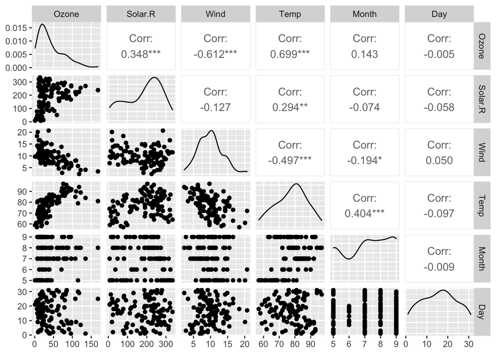

```r
ggpairs (air2) #generalized pairs plot
```

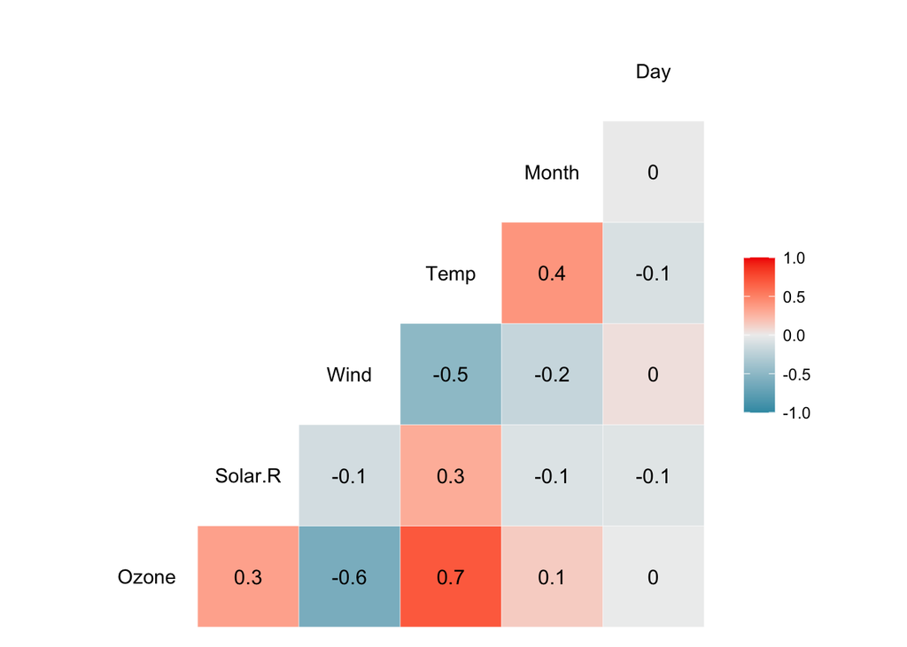

```r
ggcorr (air2, label = TRUE) #Correlation matrix
```

*Question 7 Which variable is most strongly correlated with the “Ozone” variable?*

Q7: As we can see from the correlation matrix above. “Temp” is most strongly correlated with the “Ozone” variable with a correlation of 0.7.

*Question 8 Which variable is least strongly correlated with the “Ozone” variable?*

Q8: As we can see from the correlation matrix above. “Day” is least strongly correlated with the “Ozone” variable with a correlation of 0.

*Question 9 Plot “Temp” (x axis) versus “Ozone” (y axis) using the “ggplot” function. Choose an appropriate chart type. Which statement best describes the relationship between “Temp” and “Ozone”?*

```r
##esquisser(air2) using esquisser package to help with ggplot
```

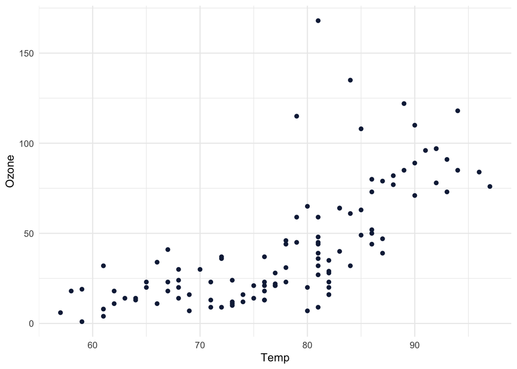

```r
ggplot(air2) +
  aes(x = Temp, y = Ozone) +
  geom_point(shape = "circle", size = 1.5, colour = "#112446") +
  theme_minimal()
```

Q9: As shown by the chart above, as Temp increases, Ozone increases. This is also in alignment with our previously found correlation coefficient of +0.7 (correlation matrix).

*Use Tidymodels to create a linear regression model using “Temp” to predict “Ozone”. You may wish to call your model fit “lm_fit”.*

```r
#reusing code from before (just changing names where needed)
air2_simple = recipe(Ozone ~ Temp, air2)

lm_model = #give the model type a name
  linear_reg() %>% #specify that we are doing linear regression
  set_engine("lm") #specify the specify type of linear tool we want to use

lm_wflow =
  workflow() %>%
  add_model(lm_model) %>%
  add_recipe(air2_simple)

lm_fit = fit(lm_wflow,air2)
```

```r
summary(lm_fit$fit$fit$fit)
```

```
##
## Call:
## stats::lm(formula = ..y ~ ., data = data)
##
## Residuals:
##     Min      1Q  Median      3Q     Max
## -40.922 -17.459  -0.874  10.444 118.078
##
## Coefficients:
##              Estimate Std. Error t value Pr(>|t|)
## (Intercept) -147.6461    18.7553  -7.872 2.76e-12 ***
## Temp           2.4391     0.2393  10.192  < 2e-16 ***
## ---
## Signif. codes:  0 '***' 0.001 '**' 0.01 '*' 0.05 '.' 0.1 ' ' 1
##
## Residual standard error: 23.92 on 109 degrees of freedom
## Multiple R-squared:  0.488,  Adjusted R-squared:  0.4833
## F-statistic: 103.9 on 1 and 109 DF,  p-value: < 2.2e-16
```

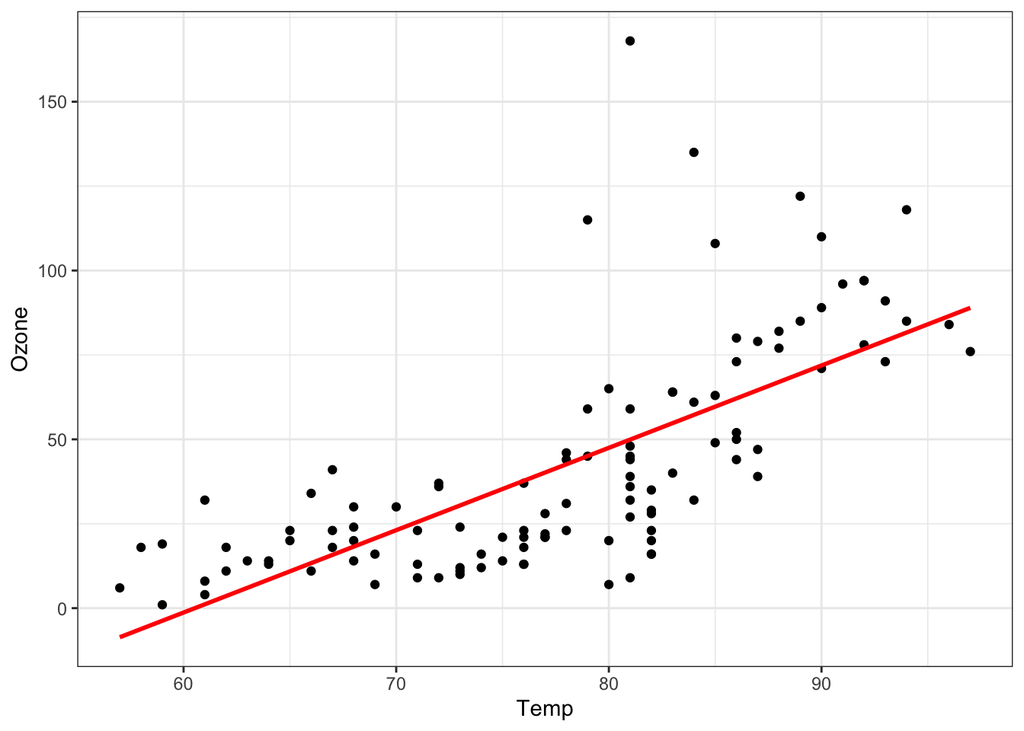

```r
ggplot(air2, aes(x=Temp,y=Ozone)) + geom_point() +
  geom_smooth(method="lm",se=FALSE, color="red") + theme_bw()
```

**Question 10** What is the slope of this regression model (to four decimal places)?

Q10: 2.4391

**Question 11** what is the R-squared value of this model (not Adjusted R-squared) (to three decimal places)?

Q11: 0.488

**Question 12** Is the “Temp” variables significant in the model?

Q12: Yes, because p-value < 0.05

```r
confint(lm_fit$fit$fit$fit, level = 0.90)
```

```
##                    5 %       95 %
## (Intercept) -178.76016 -116.53198
## Temp           2.04209    2.83613
```

Q13: True

**Question 14**: Using your linear regression model with “Temp” to predict “Ozone”, what is the predicted “Ozone” value when “Temp” is equal to 80 (to two decimal places)?

Prediction for Temp of 80?

```r
#Manually
-147.6461 + 2.4391*80
```

```
## [1] 47.4819
```

```r
#Using predict function
testdata = data.frame(Temp = 80)
predict(lm_fit, new_data = testdata)
```

```
## # A tibble: 1 × 1
##   .pred
##   <dbl>
## 1  47.5
```

Q14: 47.48

**Question 15** Perform appropriate model diagnostics to verify whether or not the model appears to meet the four linear regression model assumptions.

How does this model look?

How do we fare as far as our linear regression assumptions go?

**Assumption 1:** The predictor and response variable have a linear relationship

**Assumption 2:** Model errors (residuals) are independent  
Let’s use the Durbin-Watson Test to examine independence of residuals. The dwtest function is from the lmtest package.

```r
dwtest(lm_fit$fit$fit$fit)
```

```
##
##  Durbin-Watson test
##
## data:  lm_fit$fit$fit$fit
## DW = 1.8644, p-value = 0.2123
## alternative hypothesis: true autocorrelation is greater than 0
```

We fail to reject the null hypothesis with a p-value greater than 0.05. This suggests that the residuals are likely independent.

**Assumption 3:** Model residuals exhibit constant variance  
Examine a plot of residuals.

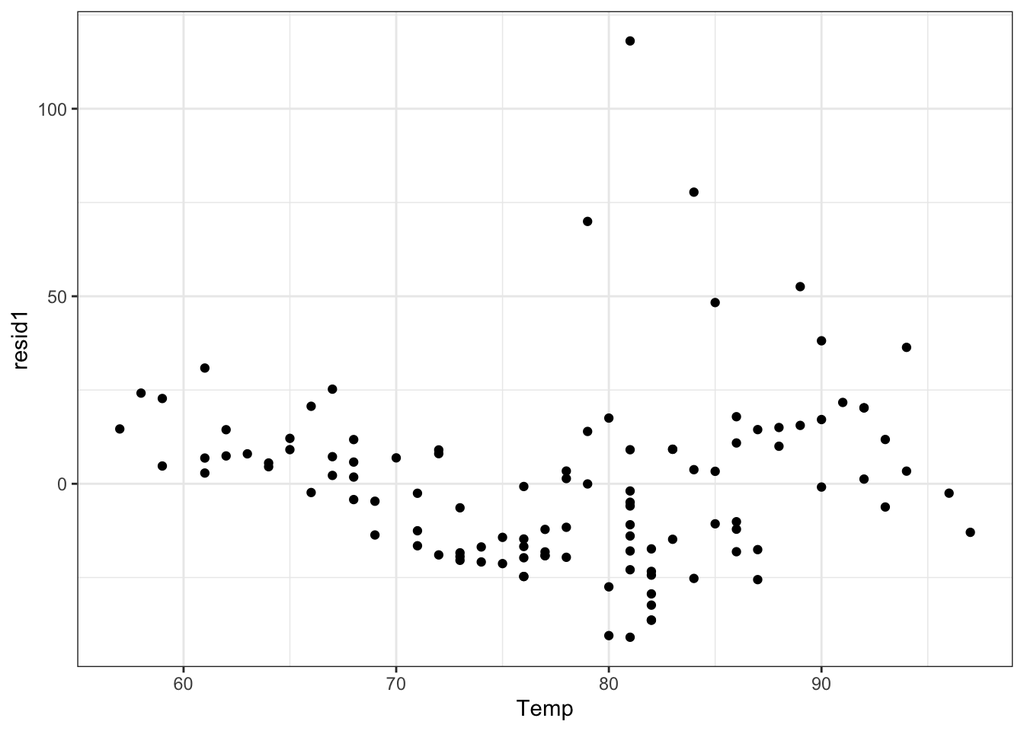

```r
air2 = air2 %>% mutate(resid1 = lm_fit$fit$fit$fit$residuals) #add the model residuals to our data frame
ggplot(air2,aes(x=Temp,y=resid1)) + geom_point() + theme_bw()
```

**Assumption 4:** Model residuals are Normally-distributed  
Examine a histogram of the residuals.

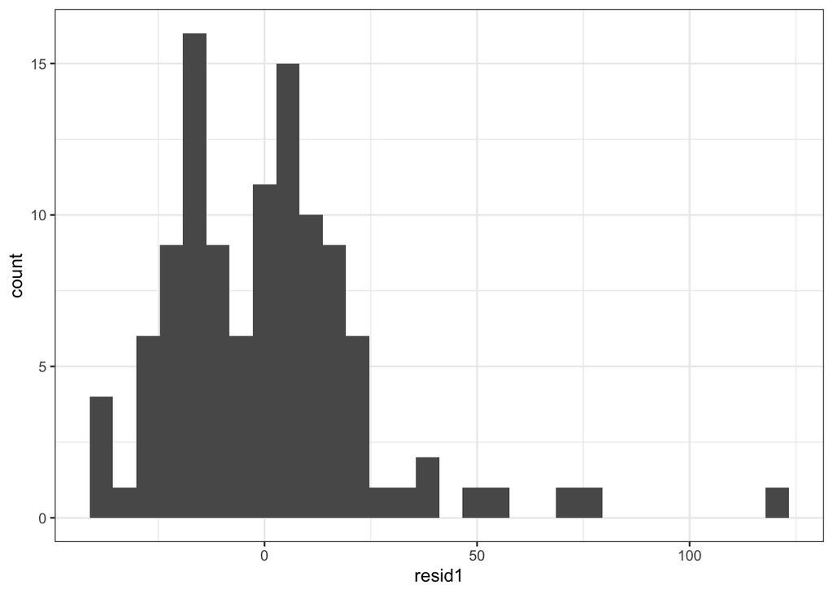

```r
ggplot(air2,aes(x=resid1)) + geom_histogram() + theme_bw()
```

The residuals histogram is not what we would likely call normally distributed.

True/False: There is no evidence of non-independent (autocorrelated) residuals.

Q15: True.